# Lista 2

Otimização e máxima verossimilhança

Autor

Afiliação

Carolina Musso 251103768

Mestrado Acadêmico em Estatística - UnB

Data de Publicação

14 de abril de 2025

## 1 Exercício 1

Seja $T$ uma variável aleatória seguindo uma distribuição Birnbaum-Saunders. Então, $T$ é definido por:

$$T = \beta \left( \frac{\alpha}{2} Z + \sqrt{\left(\frac{\alpha}{2} Z\right)^2 + 1} \right)^2,$$
em que $\alpha > 0$ e $\beta > 0$ são parâmetros de forma e escala, respectivamente, e $Z$ é uma variável aleatória com distribuição normal padrão. Temos a notação $T \sim BS(\alpha, \beta)$. O parâmetro $\beta$ é também um parâmetro de localização, pois ele é a mediana da distribuição de $T$.

Note que se $T \sim BS(\alpha, \beta)$, então

$$Z = \frac{1}{\alpha} \left( \sqrt{\frac{T}{\beta}} - \sqrt{\frac{\beta}{T}} \right) \sim N(0, 1).$$

A função densidade de probabilidade de $T$ é dada por:

$$f_T(t) = \frac{1}{\sqrt{2\pi}} \exp\left(-\frac{1}{2\alpha^2}\left[\frac{t}{\beta} + \frac{\beta}{t} - 2\right]\right) \frac{t^{-\frac{3}{2}}\left[t + \beta\right]}{2\alpha \sqrt{\beta}},$$
para $t > 0$.

Uma forma alternativa de expressar a densidade dada na equação anterior é:

$$f_T(t) = \phi(a_t) A_t; t >0, \alpha >0, \beta >0$$

em que $A_t$ é a derivada de $a_t$ com respeito a $t$,

$$a_t(\alpha, \beta) = \frac{1}{\alpha} \left( \sqrt{\frac{t}{\beta}} - \sqrt{\frac{\beta}{t}} \right),$$

que é expresso como

Seja $T_1, T_2, \ldots, T_n$ uma amostra aleatória de tamanho $n$ de $T \sim BS(\alpha, \beta)$, e seja $t_1, t_2, \ldots, t_n$ as correspondentes observações. A função de log-verossimilhança para $\theta = (\alpha, \beta)$ é dada por

$$\ell(\theta) = c_1 + \frac{n}{\alpha^2} - \frac{1}{2\alpha^2} \sum_{i=1}^n \left( \frac{t_i}{\beta} + \frac{\beta}{t_i} \right) - n \log(\alpha) - \frac{n}{2} \log(\beta) + \sum_{i=1}^n \log(t_i + \beta),$$

em que $c_1$ é uma constante que não depende de $\theta$.

Para maximizar a função de log-verossimilhança $\ell(\theta)$, precisamos das primeiras derivadas em relação a $\alpha$ e $\beta$ formando o vetor escore definido por

$$\dot{\ell} = \begin{pmatrix} \dot{\ell}_\alpha \\ \dot{\ell}_\beta \end{pmatrix},$$

cujo elementos são dados por:

A matriz Hessiana é dada por:

$$\ddot{\ell} = \begin{pmatrix} \ddot{\ell}_{\alpha\alpha} & \ddot{\ell}_{\alpha\beta} \\ \ddot{\ell}_{\beta\alpha} & \ddot{\ell}_{\beta\beta} \end{pmatrix}, i, j = 1,2$$

em que

$$\ddot{\ell}_{\alpha\alpha} = \frac{6n}{\alpha^4} - \frac{3}{\alpha^4} \sum_{i=1}^n \left( \frac{t_i}{\beta} + \frac{\beta}{t_i} \right)+\frac{n}{\alpha^2},$$

$$\ddot{\ell}_{\alpha\beta} = \ddot{\ell}_{\beta\alpha} = \frac{1}{\alpha^3} \sum_{i=1}^n \left( \frac{1}{t_i} - \frac{t_i}{\beta^2} \right),$$

$$\ddot{\ell}_{\beta\beta} = -\frac{1}{\alpha^2\beta^3}\sum_{i=1}^nt_i + \frac{n}{2\beta^2}- \sum_{i=1}^n \frac{1}{(t_i + \beta)^2}.$$

Gere uma amostra simulada de tamanho $n = 100$ da distribuição Birnbaum-Saunders com $\alpha = 0.5$ e $\beta = 2.0$. Estime os parâmetros $\alpha$ e $\beta$ através do método da máxima verossimilhança (usando o método de Newton) baseado na amostra simulada (pode usar como valores iniciais $\alpha_0 = 0.1$ e $\beta_0 = 1.0$).

### 1.1 Solução

Primeiramente, geremos uma amostra simulada de tamanho $n = 100$ da distribuição Birnbaum-Saunders com $\alpha = 0.5$ e $\beta = 2.0$.

```r
set.seed(123)
a <- 0.5
B <- 2
n <- 100

Z <- rnorm(n)
```

Em seguida, com esses elementos, vamos gerar as amostras de $T$.

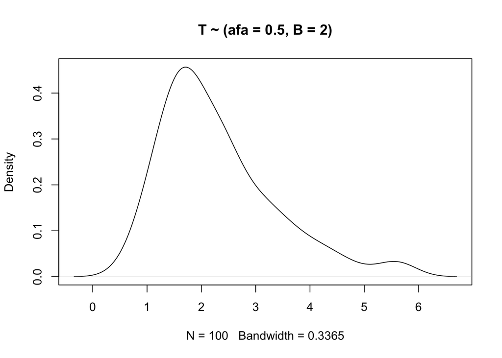

```r
t <- B * ((a / 2) * Z + sqrt(((a/2)*Z)^2+ 1))^2
plot(density(t), main = "T ~ (afa = 0.5, B = 2)")
```

Agora, precisaríamos definir a função de log-verossimilhança e calcular suas derivadas. Entretanto, o exercício já forneceu as derivadas necessárias para a implementação do método. Diferentemente do que fizemos em sala, dessa vez faremos para uma matriz (2 entradas) de parâmetros, e não apenas um como nos exemplos das notas de aula. Isso irá afetar a parte final da implementação, onde teremos que inverter a matriz Hessiana (que seria intuitivamente equivalente $\frac{1}{\ddot{l}}$.  
Usando como inspiração o código implementado em sala, propusemos os seguintes critérios de parada: um $\varepsilon < 1^{-10}$, um máximo de interações de 15.

```r
theta <- list()
theta[[1]] <- c(0.1, 1)

tolerance <- 1e-10
max.iter <- 15
i <- 1
converged <- FALSE

#
while (i <= max.iter & !converged) {
  a <- theta[[i]][1]
  B <- theta[[i]][2]

  ## Primeiras derivadas
  d1_a <- ((-2 * n) / (a^3)) + (1 / (a^3)) * sum((t / B) + (B / t)) - (n / a)
  d1_b <- (1 / (2 * a^2)) * sum((t / B^2) - (1 / t)) - n / (2 * B) + sum(1 / (t + B))
  l_linha <- c(d1_a, d1_b)

  ## Segunda derivadas (Hessiana)
  d2_aa <- ((6 * n) / (a^4)) - (3 / (a^4)) * sum((t / B) + (B / t)) + n / (a^2)
  d2_ab <- (1 / a^3) * sum((1 / t) - (t / (B^2)))
  d2_bb <- -1 / ((a^2) * (B^3)) * sum(t) + (n / (2 * (B^2))) - sum(1 / (t + B)^2)

  hessiana <- matrix(c(d2_aa, d2_ab,
                       d2_ab, d2_bb),
                     nrow = 2, byrow = TRUE)

  h <- solve(hessiana, l_linha)

  theta[[i + 1]] <- theta[[i]] - h

  # Verifica convergência
  delta <- abs(theta[[i + 1]] - theta[[i]]) / (abs(theta[[i]]) + tolerance)
  converged <- all(delta < tolerance)

  i <- i + 1
}

if (!converged) {
  warning("O método de Newton terminou sem convergir após 500 iterações.")
}
```

```r
# Resultado final
theta[[i]]
```

```
[1] 0.4539515 2.0913721
```

```r
i
```

```
[1] 14
```